# Analyse des consultations de santé — Cameroun 2025

De la donnée brute au dashboard : constats et recommandations

Analyste junior · Programme de santé publique

12/10/2026

## Synthèse pour la décision

**10 000 consultations** ont été analysées dans **150 établissements**, 30 districts et 10 régions du Cameroun (année 2025), après correction de 12 types d’anomalies dans les données.

1. **Les ruptures de médicaments touchent 18 % des consultations**, dans toutes les régions. L’écart entre **districts** est statistiquement significatif (p = 0,006), pas celui entre régions : l’action doit être ciblée au niveau district et établissement (Batouri 24,9 %, Ebolowa, Sangmélima, Yaoundé I, Maroua).
2. **Le coût dépend du diagnostic, et de lui seul** (p < 0,001) : le diabète (29,7 USD) et la tuberculose (28,0 USD) coûtent 3 à 4 fois plus que la diarrhée (8,1 USD).
3. **L’assurance ne change pas le coût observé** (p = 0,444) et ne couvre que **35,2 %** des patients, de façon homogène entre régions.
4. **Aucune pathologie ne domine** : les 9 diagnostics pèsent chacun environ 11 % des cas. Les « points chauds » régionaux visibles sur la carte thermique ne sont **pas** statistiquement significatifs (p = 0,101) : à confirmer avec davantage de données avant d’orienter des moyens.
5. **L’activité est stable toute l’année** (pas de saisonnalité détectable, p = 0,659).

# 1. Contexte et méthode

Le ministère de la santé collecte des consultations dans plusieurs centres. Le fichier source (10 300 lignes, 12 variables) est volontairement « sale ». La démarche suit le workflow standard d’un analyste :

| Étape | Livrable |
| --- | --- |
| 1. Import · 2. Exploration · 3. Nettoyage · 4. Transformation | `R/01_import_nettoyage.R` |
| 5. Analyse métier · 6. Visualisation · 7. Statistiques | `R/02_analyse.R` |
| 8. Dashboard interactif | `app/app.R` (Shiny) |
| 9. Reporting · 10. Recommandations | ce document |

Tout est reproductible : `Rscript run_all.R` régénère les données propres, les figures et ce rapport.

# 2. Qualité des données : de la donnée sale à la donnée fiable

| Problème | Traitement | Lignes concernées |
| --- | --- | --- |
| Doublons (patient_id répétés) | Suppression après harmonisation | 300 |
| Régions incohérentes (LITTORAL, litoral, SW, sud ouest, Ctr, CENTER, centre) | Harmonisées en 10 régions officielles | 231 |
| Régions manquantes | Imputées à partir du district (référentiel) | 518 |
| Dates au format jj/mm/aaaa | Converties en date ISO | 200 |
| Genre : modalités mixtes (M, F, male, Feminin…) | Harmonisé : Féminin / Masculin | 978 |
| Genre manquant | Laissé NA (non imputable) | 512 |
| Diagnostic manquant | Laissé NA, exclu des analyses épidémiologiques | 800 |
| Assurance manquante | Laissée NA | 520 |
| Coût manquant | Laissé NA (exclu des moyennes) | 516 |
| Coûts aberrants (<=0 ou >1000 : -100, 9999, 50000) | Mis à NA | 50 |
| Âges impossibles (<0 ou >120 : -5, 140, 222) | Mis à NA | 50 |
| Âge = 0 (pic artificiel, valeur par défaut probable) | Mis à NA | 537 |

**Décisions de méthode à connaître**

- **Région manquante (518 lignes)** : récupérée à 100 % grâce au district, qui détermine la région sans ambiguïté dans les données.
- **Âge = 0 (537 lignes)** : on observe 537 âges à 0 contre 67 à 1 an. Ce pic est artificiel (valeur par défaut de saisie probable, y compris pour des consultations prénatales) : traité comme manquant.
- **Coûts −100, 9 999 et 50 000** : codes d’erreur évidents (médiane à 16 USD), mis à manquant. Le coût de 2,0 USD, répété 215 fois, ressemble à un plancher de saisie mais reste plausible : conservé.
- **Doublons** : 300 `patient_id` répétés. Après harmonisation du genre, 296 sont identiques ; 4 diffèrent légèrement, la première occurrence est conservée.
- **Valeurs manquantes restantes** (≈ 5 % par variable) : jamais imputées par la moyenne, pour ne pas fabriquer d’information.
- **Devise** : non précisée dans la source ; interprétée comme des **USD**. Hypothèse à faire valider.

| Incohérence logique résiduelle (signalée, non corrigée) | Lignes |
| --- | --- |
| Consultations prénatales de patients masculins | 996 |
| Consultations prénatales hors tranche 12-50 ans | 451 |

# 3. Résultats

## 3.1 Où se concentre l’activité ?

L’activité est répartie de façon quasi uniforme : de 951 (Sud-Ouest) à 1 068 consultations (Adamaoua) par région.

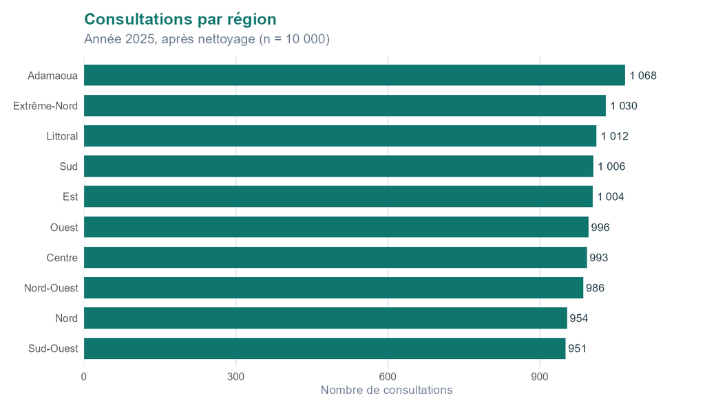

## 3.2 Quelles maladies ? Où ? Chez qui ?

Anémie est le diagnostic le plus fréquent (11,8 %), mais l’écart avec le dernier (Hypertension, 10,7 %) est faible.

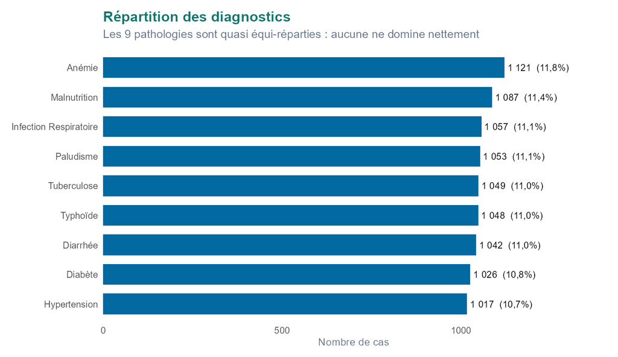

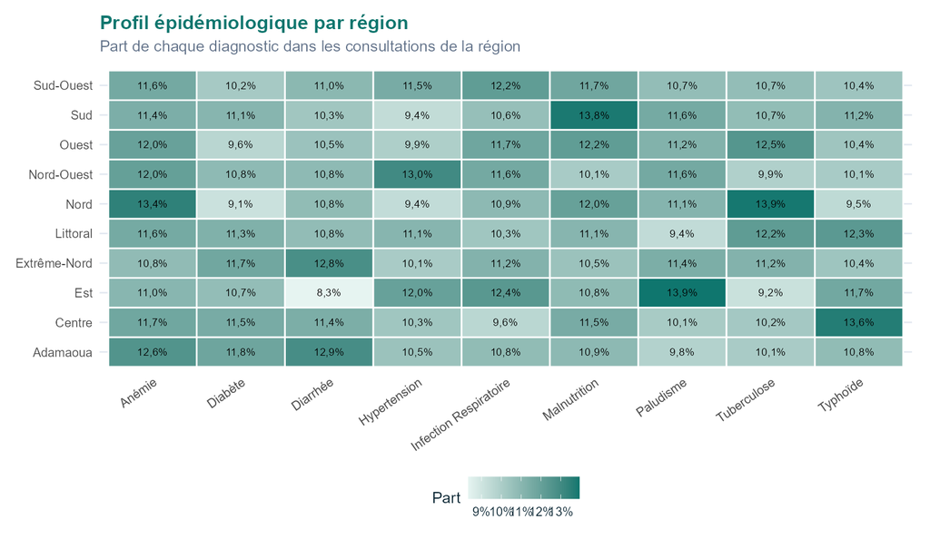

> **Lecture prudente.** Test du χ² : diagnostic × région p = 0,101, diagnostic × tranche d’âge p = 0,19, diagnostic × sexe p = 0,971. Les différences visibles sur la carte thermique sont compatibles avec le hasard : **pas de profil épidémiologique régional établi** avec ces données.

## 3.3 Combien coûtent les soins ?

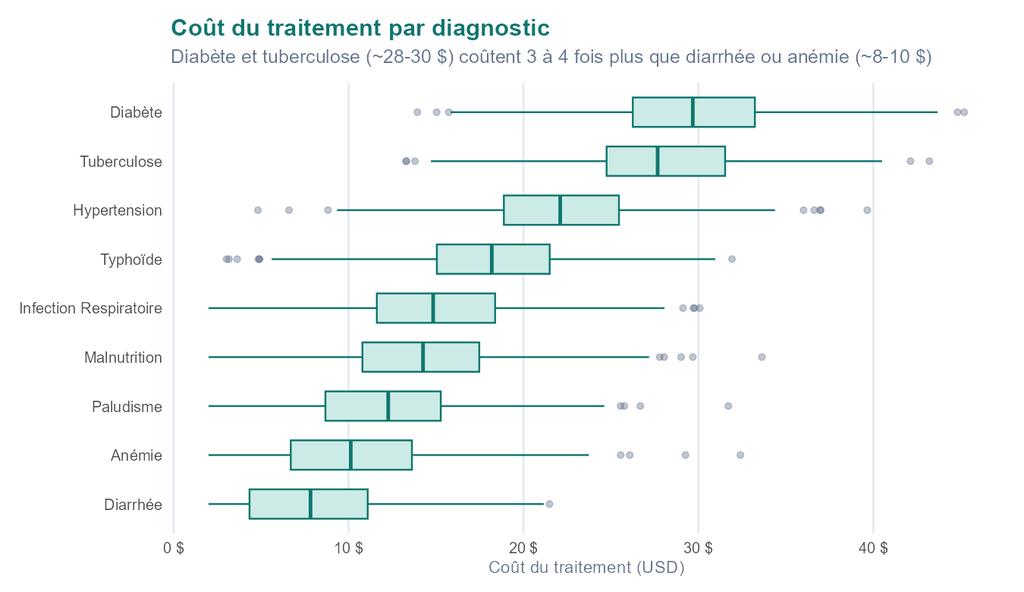

| Diagnostic | Consultations | Coût moyen | Coût médian | Coût total (USD) | Part du coût total |
| --- | --- | --- | --- | --- | --- |
| Diabète | 958 | 29,7 | 29,7 | 28 478 | 18,2 % |
| Tuberculose | 1 002 | 28,0 | 27,7 | 28 051 | 17,9 % |
| Hypertension | 957 | 22,1 | 22,1 | 21 181 | 13,6 % |
| Typhoïde | 991 | 18,2 | 18,2 | 18 057 | 11,6 % |
| Infection Respiratoire | 988 | 15,1 | 14,8 | 14 900 | 9,5 % |
| Malnutrition | 1 027 | 14,1 | 14,3 | 14 519 | 9,3 % |
| Paludisme | 999 | 12,1 | 12,3 | 12 094 | 7,7 % |
| Anémie | 1 071 | 10,3 | 10,1 | 11 033 | 7,1 % |
| Diarrhée | 986 | 8,1 | 7,8 | 7 982 | 5,1 % |

Diabète et tuberculose représentent 36 % du coût total pour 22 % des cas : ce sont les pathologies qui pèsent le plus sur le budget.

## 3.4 Assurance

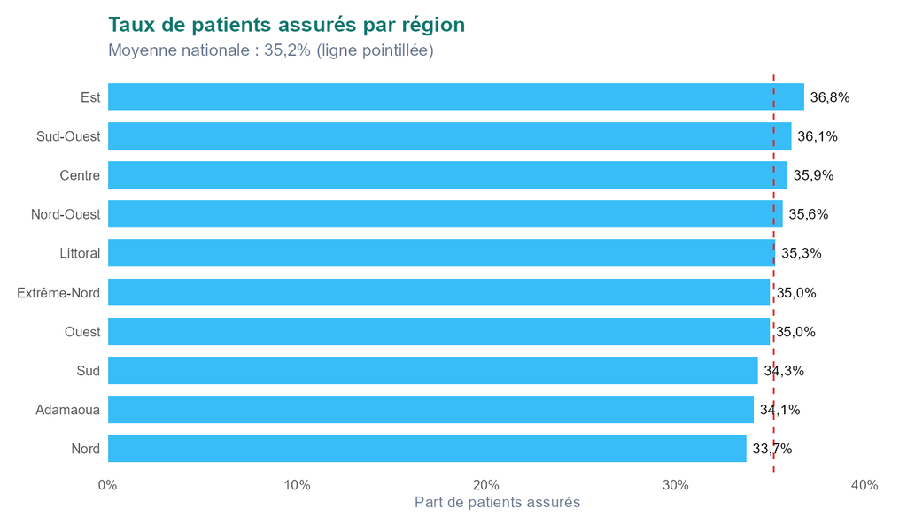

Le coût moyen est quasi identique pour les assurés (17,36 USD) et les non-assurés (17,45 USD). La couverture varie peu d’une région à l’autre (de 33,7 % à 36,8 %).

## 3.5 Disponibilité des médicaments

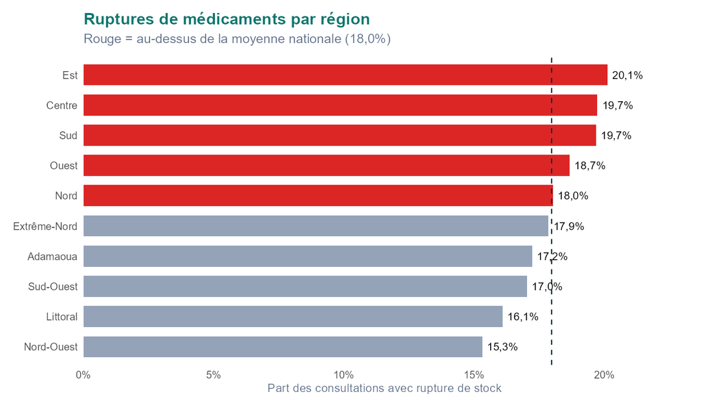

Les 8 districts les plus touchés

| District | Région | Consultations | Taux de rupture |
| --- | --- | --- | --- |
| Batouri | Est | 338 | 24,9 % |
| Ebolowa | Sud | 351 | 22,8 % |
| Sangmélima | Sud | 345 | 22,3 % |
| Yaoundé I | Centre | 332 | 22,3 % |
| Maroua | Extrême-Nord | 326 | 21,5 % |
| Mbalmayo | Centre | 349 | 19,5 % |
| Dschang | Ouest | 344 | 19,5 % |
| Kumba | Sud-Ouest | 309 | 18,8 % |

Le taux de rupture ne dépend ni du diagnostic (p = 0,809) ni du statut d’assurance (p = 0,417) : c’est un problème d’**approvisionnement par site**, pas de type de patient. Il est maximal en janvier (20,5 %) et en novembre (19,8 %).

## 3.6 Dynamique mensuelle

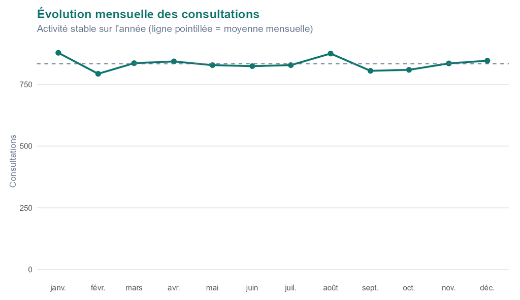

# 4. Statistiques descriptives

| Variable | n | Moyenne | Médiane | Écart-type | Variance | Min | Q1 | Q3 | Max | CV | Asymétrie |
| --- | --- | --- | --- | --- | --- | --- | --- | --- | --- | --- | --- |
| Âge | 9 429 | 31,70 | 31,00 | 16,23 | 263,33 | 1 | 19,00 | 43,00 | 95,00 | 0,51 | 0,36 |
| Coût (USD) | 9 450 | 17,39 | 16,36 | 8,68 | 75,36 | 2 | 10,88 | 23,57 | 45,19 | 0,50 | 0,34 |

L’âge (moyenne 31,7 ans, médiane 31) et le coût (moyenne 17,4, médiane 16,4 USD) ont des distributions peu asymétriques et proches d’une cloche, une fois les valeurs aberrantes retirées. Avant nettoyage, la moyenne du coût était de **109 USD** à cause de quelques valeurs à 9 999 et 50 000 : un exemple concret de l’intérêt du nettoyage.

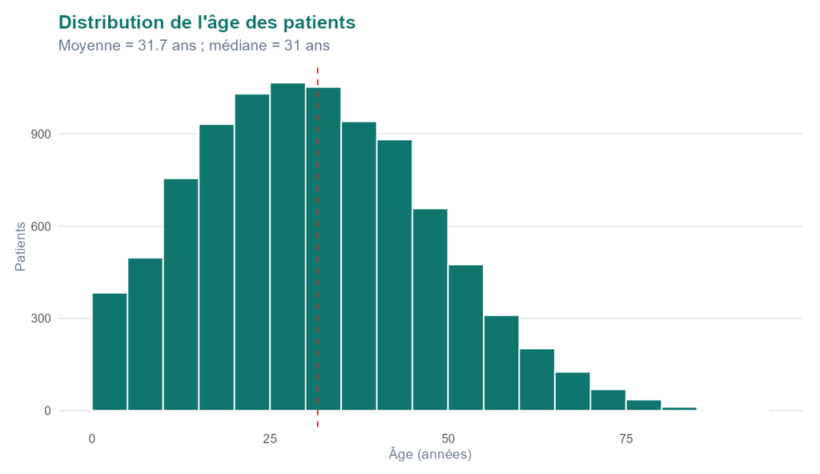

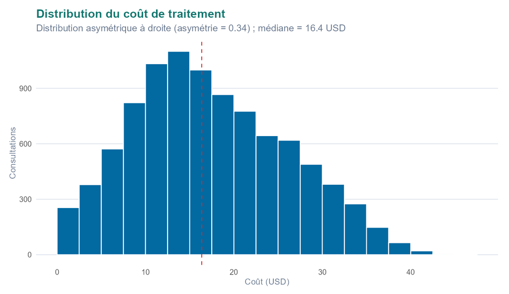

## Tests d’hypothèses (seuil 5 %)

| Comparaison | Test | p-value | Conclusion |
| --- | --- | --- | --- |
| Rupture × région | Pearson’s Chi-squared test | 0,074 | Non significatif |
| Rupture × district | Pearson’s Chi-squared test | 0,006 | **Significatif** |
| Rupture × diagnostic | Pearson’s Chi-squared test | 0,809 | Non significatif |
| Rupture × assurance | Pearson’s Chi-squared test | 0,417 | Non significatif |
| Diagnostic × région | Pearson’s Chi-squared test | 0,101 | Non significatif |
| Diagnostic × tranche d’âge | Pearson’s Chi-squared test | 0,190 | Non significatif |
| Diagnostic × sexe | Pearson’s Chi-squared test | 0,971 | Non significatif |
| Coût × diagnostic | Kruskal-Wallis | < 0,001 | **Significatif** |
| Coût × assurance | Wilcoxon with continuity correction | 0,444 | Non significatif |
| Coût × type de consultation | Kruskal-Wallis | 0,111 | Non significatif |
| Coût × région | Kruskal-Wallis | 0,971 | Non significatif |
| Âge × coût (corrélation) | Spearman’s rank correlation rho | 0,096 | Non significatif |

Seuls **deux** effets sont solides : le coût varie avec le diagnostic, et le taux de rupture varie entre districts.

# 5. Recommandations

[output not shown]

## Limites

- Données **simulées** : les faibles écarts entre régions reflètent probablement ce caractère synthétique ; l’analyse reste valable comme démarche.
- Devise du coût à confirmer ; âge 0 traité comme manquant (vrais nourrissons possibles, mais le pic observé est trop marqué pour être naturel).
- Les seuils de significativité sont indicatifs ; une comparaison de nombreux sous-groupes augmente le risque de faux positifs.

# 6. Dashboard

Le tableau de bord interactif (`shiny::runApp("app")`) reprend ces analyses avec des filtres combinables (période, région, diagnostic, type de consultation, sexe, assurance) : vue d’ensemble, épidémiologie, carte des districts, médicaments, coûts et assurance, qualité des données, export CSV.